# Anastasia Sosnovskikh - Bitcoin Project

## 1. Research Question

#### 1.1 Motivation

I want to work with **financial / stock time series data** for this project. The motivation for the research topic comes from my personal interest as well as the increased interest in cryptocurency in the past few years.

First, I have been hearing a lot about stock data and trading, especially from the Computer Science community and friends, but I have never done anything related to trading. Therefore, I hope to learn more about it in the course of this project. Moreover, I hope that it would be useful for me in the future as I might either start investing myself or work in the trading / financial field.

Second, for this project, I wanted to work with time series data specifically because I wanted to get more practice with something I have never worked before. Time series differs from the other types of data since many of the metrics and approaches I have learned before are not applicable here. I understand that choosing this problem would require more work and supervision but that is exactly my goal to learn more! I want to study stock data on day-to-day basic since I think it’s the most appropriate scale for me as a “regular” investor.

For the data, I chose the **Bitcoin** which is the world’s most "popular" cryptocurrency and it has an open nature since not much is knownw about it or its relations to other variables or currencies.

#### 1.2 Literature

There is a little professional research being done in the field of Machine Learning where people try to predict the bitcoin price, but some is still present [1]. What’s relevant for me to get from the sources is the *background information* on bitcoin including what *exogenous variables* might be useful to consider, and what *models* people thought would work best for this type of problem.

##### 1.2.1 Methods

McNally et al. [1] argues that “traditional time series prediction methods such as Holt-Winters exponential smoothing models rely on linear assumptions and require data that can be broken down into trend, seasonal and noise to be effective” which means that “this type of methodology is more suitable for a task such as forecasting sales where seasonal effects are present.” And since there is a lack of seasonality in the Bitcoin market and it’s also highly volatile, the authors suggest using deep learning methods instead. McNally et al. argues that “the recurrent neural network (`RNN`) and the long short-term memory (`LSTM`) are favored over the traditional multilayer perceptron (`MLP`) due to the temporal nature of Bitcoin data.” [1] mentions other papers in the intro that have used `SVM`, artificial neural networks (`ANN`), `Random Forest`s, and `Binomial GLM` with some prediction accuracy of over 97%. Although, they did not cross-validate their models which questions their generatability. As a note, I cite this first paper more than others because I stumbled upon it first, but they may be wrong in their assumptions! I would have to continually look into other papers and read more on the topic prior to diving into the final project.

Some also have implemented the MultiLayer Perceptron (`ML`) for stock price prediction, but I am not sure what it is; McNally et al. say that it’s not the best since it analyses one observation at a time. Akcora et al. (2018) represent the problem as a `Graph` problem [2]! A paper by Waheeb et al. (2020) is important because it compares different statistical and ML methods for Bitcoin price forecasting [3]. They used 13 models to predict the Bitcoin data for the next 14 days. The forecasting methods were “average, naive, drift, auto-regressive integrated moving-average, simple exponential smoothing (SES), Holt, and damped exponential smoothing, the average of SES, Holt and damped methods, exponential smoothing (ETS), bagged ETS, Theta, multilayer perceptron, and extreme learning machines (ELM).” I have no idea what they are so I would have to look into what they did. Just in case if you are interested, they found out that “first, there are seven forecasting methods outperformed the naive method namely `MLP`, `ELM`, `damped exponential smoothing`, `simple exponential smoothing`, `Theta`, `ETS`, and `ARIMA`. Second, `MLP` and `ELM` showed better forecasting accuracy on both validation and out-of-sample data. Third, the size of the training data is essential factor that should be considered when training forecasting methods” [3]. The last finding seems important, so for the actual project I will try to find the Bitcoin data from the earliest year I can find. I know that one research mentioned they had data starting from 2009, so I might look into where they got it or email them directly [2].

There were other models used in the papers. [4] used `neural networks`, `SVM`, and `deep learning models` with `SVM` ending up being the best. [5] used “`ARIMA` and `non-linear autoregressive model with exogenous inputs (NARX)` based on multi-layer perceptron (`MLP`) method”; not entirely sure what these are. [6] used `RNN` and `LSTM` (just as [1] did I think) along with 10-fold cross validation. [7] used `CNN-LSTM hybrid model`. For the performance metric, I have seen people use `RMSE`, `MAE`, and others.

##### 1.2.2 Exogenous Variables

As some sources say, people have been using `text` from various social media platforms and websites (e.g., Twitter, Reddit, Google Trends [8]) to predict Bitcoin price. Some people have looked at the frequency of Wikipedia views and network hash rate to predict the volume of Bitcoin being traded [from 1]. For the limitations, small sample sizes and the propensity of misinformation were mentioned which makes the market suffer from risk of manipulation. [9] mentions that there is a strong correlation between Bitcoin transactions and transaction fees and bitcoin price (which is expected I think) and a correlation with `gold`, `crude oil` price, `NASDAQ`, `DAX`, and `S&P500`; I should definitely look at those too! It might be the case that I find other information since that paper was published in 2017, and the market changes a lot! Overall, still, many papers just looked at the raw Bitcoin data and nothing else.

#### 1.3 Contribution to the area of study

Given that some people in the field (not only in the blog posts!) are trying to predict the Bitcoin prices by comparing different models and doing essentially what we are trying to do for this final project, I think that I can contribute a little! At the very least, I can try to run models I already know about like `neural networks`, `RF`, `SVM`, and see how they compare to each other. It is interesting that papers appearing first on Google Scholar search are from 2018, and Roy et al. (2018) mention that 2017 is a “Bitcoin boom” year [10]. From the visualizations we see further in this proposal, it is evident that 2021 is the real Bitcoin boom year compared to 2017; therefore, we might expect to see more papers on this topic in the near future! Maybe I should try to publish something too?.. :)

#### 1.4 Bibliography

[1] S. McNally, J. Roche and S. Caton, "Predicting the Price of Bitcoin Using Machine Learning," 2018 26th Euromicro International Conference on Parallel, Distributed and Network-based Processing (PDP), Cambridge, UK, 2018, pp. 339-343, doi: 10.1109/PDP2018.2018.00060.

[2] Akcora C.G., Dey A.K., Gel Y.R., Kantarcioglu M. (2018) Forecasting Bitcoin Price with Graph Chainlets. In: Phung D., Tseng V., Webb G., Ho B., Ganji M., Rashidi L. (eds) Advances in Knowledge Discovery and Data Mining. PAKDD 2018. Lecture Notes in Computer Science, vol 10939. Springer, Cham. doi.org/10.1007/978-3-319-93040-4_60

[3] W. Waheeb, H. Shah, M. Jabreel and D. Puig, "Bitcoin Price Forecasting: A Comparative Study Between Statistical and Machine Learning Methods," 2020 2nd International Conference on Computer and Information Sciences (ICCIS), Sakaka, Saudi Arabia, 2020, pp. 1-5, doi: 10.1109/ICCIS49240.2020.9257664.

[4] N. Hitam and A. Ismail, "Comparative performance of machine learning algorithms for cryptocurrency forecasting", Ind. J. Electr. Eng. Comput. Sci, vol. 11, no. 3, pp. 1121-1128, 2018.

[5] C.C. Tun and N. Majid, "Comparison between artificial neural network and autoregressive integrated moving average model in bitcoin price forecasting", Journal of Quality Measurement and Analysis JQMA, vol. 14, no. 2, pp. 45-53, 2018.

[6] S. Tandon, S. Tripathi, P. Saraswat and C. Dabas, "Bitcoin Price Forecasting using LSTM and 10-Fold Cross validation," 2019 International Conference on Signal Processing and Communication (ICSC), NOIDA, India, 2019, pp. 323-328, doi: 10.1109/ICSC45622.2019.8938251.

[7] Li, Yan, and Wei Dai. "Bitcoin price forecasting method based on CNN‐LSTM hybrid neural network model." The Journal of Engineering 2020.13 (2020): 344-347.

[8] Kristoufek, Ladislav. "BitCoin meets Google Trends and Wikipedia: Quantifying the relationship between phenomena of the Internet era." Scientific reports 3.1 (2013): 1-7.

[9] Vassiliadis, Savvas, et al. "Bitcoin value analysis based on cross-correlations." Journal of Internet Banking and Commerce 22.S7 (2017): 1.

[10] S. Roy, S. Nanjiba and A. Chakrabarty, "Bitcoin Price Forecasting Using Time Series Analysis," 2018 21st International Conference of Computer and Information Technology (ICCIT), Dhaka, Bangladesh, 2018, pp. 1-5, doi: 10.1109/ICCITECHN.2018.8631923.

P.S. For some papers, Pitt does not give a free access, but I still do **have access to them** from the University of New South Wales (I studied abroad in Australia). Let me know if you are interested in any of these and cannot find them available freely, I’d be happy to send them to you!

## 2. Data Undestanding

### 2.1 Import Modules

Import relevant modules in one place.

```python
import numpy as np
import pandas as pd
import ssl  # we need to import this library and tweak one setting due to fact we use HTTPS certificate(s) to read the data
import matplotlib.pyplot as plt

import seaborn as sns
sns.set(rc={'figure.figsize':(16,8)}) # set the figure size for all sns plots
#sns.set_palette('flare')
```

### 2.2 Read Data

```python
filepath = "https://www.cryptodatadownload.com/cdd/Binance_BTCUSDT_d.csv" # get the path to the .csv file
ssl._create_default_https_context = ssl._create_unverified_context

df = pd.read_csv(filepath, skiprows=1) # row 1 is the web-address
df.head()
```

|  | unix | date | symbol | open | high | low | close | Volume BTC | Volume USDT | tradecount |
| --- | --- | --- | --- | --- | --- | --- | --- | --- | --- | --- |
| 0 | 1.615507e+12 | 2021-03-12 00:00:00 | BTC/USDT | 57773.15 | 58081.51 | 57773.15 | 57934.94 | 439.973288 | 2.549123e+07 | 13226.0 |
| 1 | 1.615421e+12 | 2021-03-11 00:00:00 | BTC/USDT | 55851.59 | 58150.00 | 54272.82 | 57773.16 | 81914.812859 | 4.612366e+09 | 2509970.0 |
| 2 | 1.615334e+12 | 2021-03-10 00:00:00 | BTC/USDT | 54874.67 | 57387.69 | 53005.00 | 55851.59 | 84749.238943 | 4.700198e+09 | 2647284.0 |
| 3 | 1.615248e+12 | 2021-03-09 00:00:00 | BTC/USDT | 52375.18 | 54895.00 | 51789.41 | 54884.50 | 71656.737076 | 3.861451e+09 | 2194398.0 |
| 4 | 1.615162e+12 | 2021-03-08 00:00:00 | BTC/USDT | 50959.11 | 52402.78 | 49274.67 | 52375.17 | 66987.359664 | 3.400848e+09 | 1999401.0 |

#### 2.2.1 Change column names

```python
# Column names: remove white spaces, convert to lower case, add _ instead of space
df.columns = df.columns.str.strip().str.lower().str.replace(' ','_')
df.head()
```

|  | unix | date | symbol | open | high | low | close | volume_btc | volume_usdt | tradecount |
| --- | --- | --- | --- | --- | --- | --- | --- | --- | --- | --- |
| 0 | 1.615507e+12 | 2021-03-12 00:00:00 | BTC/USDT | 57773.15 | 58081.51 | 57773.15 | 57934.94 | 439.973288 | 2.549123e+07 | 13226.0 |
| 1 | 1.615421e+12 | 2021-03-11 00:00:00 | BTC/USDT | 55851.59 | 58150.00 | 54272.82 | 57773.16 | 81914.812859 | 4.612366e+09 | 2509970.0 |
| 2 | 1.615334e+12 | 2021-03-10 00:00:00 | BTC/USDT | 54874.67 | 57387.69 | 53005.00 | 55851.59 | 84749.238943 | 4.700198e+09 | 2647284.0 |
| 3 | 1.615248e+12 | 2021-03-09 00:00:00 | BTC/USDT | 52375.18 | 54895.00 | 51789.41 | 54884.50 | 71656.737076 | 3.861451e+09 | 2194398.0 |
| 4 | 1.615162e+12 | 2021-03-08 00:00:00 | BTC/USDT | 50959.11 | 52402.78 | 49274.67 | 52375.17 | 66987.359664 | 3.400848e+09 | 1999401.0 |

#### 2.2.2 Change data types

```python
# convert date to datetime
df['date'] = pd.to_datetime(df['date'])
df.dtypes
```

```
unix                  float64
date           datetime64[ns]
symbol                 object
open                  float64
high                  float64
low                   float64
close                 float64
volume_btc            float64
volume_usdt           float64
tradecount            float64
dtype: object
```

### 2.3 Exploratory data information

#### 2.3.1 The number of rows and columns in dataset(s)

```python
# dimentions
df.shape
```

```
(1305, 10)
```

```python
# count
df.count()
```

```
unix           1305
date           1305
symbol         1305
open           1305
high           1305
low            1305
close          1305
volume_btc     1305
volume_usdt    1305
tradecount     1181
dtype: int64
```

```python
# glimpse
df.head()
```

|  | unix | date | symbol | open | high | low | close | volume_btc | volume_usdt | tradecount |
| --- | --- | --- | --- | --- | --- | --- | --- | --- | --- | --- |
| 0 | 1.615507e+12 | 2021-03-12 | BTC/USDT | 57773.15 | 58081.51 | 57773.15 | 57934.94 | 439.973288 | 2.549123e+07 | 13226.0 |
| 1 | 1.615421e+12 | 2021-03-11 | BTC/USDT | 55851.59 | 58150.00 | 54272.82 | 57773.16 | 81914.812859 | 4.612366e+09 | 2509970.0 |
| 2 | 1.615334e+12 | 2021-03-10 | BTC/USDT | 54874.67 | 57387.69 | 53005.00 | 55851.59 | 84749.238943 | 4.700198e+09 | 2647284.0 |
| 3 | 1.615248e+12 | 2021-03-09 | BTC/USDT | 52375.18 | 54895.00 | 51789.41 | 54884.50 | 71656.737076 | 3.861451e+09 | 2194398.0 |
| 4 | 1.615162e+12 | 2021-03-08 | BTC/USDT | 50959.11 | 52402.78 | 49274.67 | 52375.17 | 66987.359664 | 3.400848e+09 | 1999401.0 |

```python
# describe
df.describe()
```

|  | unix | open | high | low | close | volume_btc | volume_usdt | tradecount |
| --- | --- | --- | --- | --- | --- | --- | --- | --- |
| count | 1.305000e+03 | 1305.000000 | 1305.000000 | 1305.000000 | 1305.000000 | 1305.000000 | 1.305000e+03 | 1.181000e+03 |
| mean | 1.416014e+12 | 10353.604008 | 10691.909686 | 9986.355418 | 10394.581280 | 47295.745457 | 6.025386e+08 | 5.902356e+05 |
| std | 4.593748e+11 | 8581.874320 | 8969.212530 | 8194.836261 | 8680.813073 | 35745.583075 | 9.478735e+08 | 5.898839e+05 |
| min | 1.502928e+09 | 3189.020000 | 3276.500000 | 2817.000000 | 3189.020000 | 225.760000 | 9.677533e+05 | 1.241700e+04 |
| 25% | 1.531008e+12 | 6458.980000 | 6584.010000 | 6315.000000 | 6463.000000 | 25954.453533 | 1.786141e+08 | 2.210750e+05 |
| 50% | 1.559174e+12 | 8301.980000 | 8549.000000 | 8088.400000 | 8330.000000 | 39972.405371 | 3.205765e+08 | 3.748320e+05 |
| 75% | 1.587341e+12 | 10542.070000 | 10849.340000 | 10200.000000 | 10564.490000 | 61571.384994 | 5.633605e+08 | 6.936940e+05 |
| max | 1.615507e+12 | 57773.150000 | 58352.800000 | 57773.150000 | 57934.940000 | 402201.673764 | 8.426880e+09 | 4.431451e+06 |

#### 2.3.3 The data types associated with each variable

```python
df.dtypes
```

```
unix                  float64
date           datetime64[ns]
symbol                 object
open                  float64
high                  float64
low                   float64
close                 float64
volume_btc            float64
volume_usdt           float64
tradecount            float64
dtype: object
```

#### 2.3.4 Number of missing values per variable

```python
# missing values
df.isna().sum()
```

```
unix             0
date             0
symbol           0
open             0
high             0
low              0
close            0
volume_btc       0
volume_usdt      0
tradecount     124
dtype: int64
```

#### 2.3.5 Number of unique values per variable

```python
# unique values
df.nunique()
```

```
unix           1305
date           1304
symbol            1
open           1303
high           1260
low            1260
close          1303
volume_btc     1305
volume_usdt    1305
tradecount     1180
dtype: int64
```

#### 2.3.6 State which variables will be considered as INPUTS and OUTPUTS to a predictive model

Since this is a forecasing problem, I will be using historical `date` and `close` values to predict the future `close` value.

### 2.4 Visualizations

```python
df = df.set_index('date') # set index
```

```python
# create new columns from datetime index
df['year'] = df.index.year
df['month'] = df.index.month
df['day'] = df.index.day
df.head()
```

| date | unix | symbol | open | high | low | close | volume_btc | volume_usdt | tradecount | year | month | day |
| --- | --- | --- | --- | --- | --- | --- | --- | --- | --- | --- | --- | --- |
| 2021-03-12 | 1.615507e+12 | BTC/USDT | 57773.15 | 58081.51 | 57773.15 | 57934.94 | 439.973288 | 2.549123e+07 | 13226.0 | 2021 | 3 | 12 |
| 2021-03-11 | 1.615421e+12 | BTC/USDT | 55851.59 | 58150.00 | 54272.82 | 57773.16 | 81914.812859 | 4.612366e+09 | 2509970.0 | 2021 | 3 | 11 |
| 2021-03-10 | 1.615334e+12 | BTC/USDT | 54874.67 | 57387.69 | 53005.00 | 55851.59 | 84749.238943 | 4.700198e+09 | 2647284.0 | 2021 | 3 | 10 |
| 2021-03-09 | 1.615248e+12 | BTC/USDT | 52375.18 | 54895.00 | 51789.41 | 54884.50 | 71656.737076 | 3.861451e+09 | 2194398.0 | 2021 | 3 | 9 |
| 2021-03-08 | 1.615162e+12 | BTC/USDT | 50959.11 | 52402.78 | 49274.67 | 52375.17 | 66987.359664 | 3.400848e+09 | 1999401.0 | 2021 | 3 | 8 |

##### 2.4.1 Lineplots

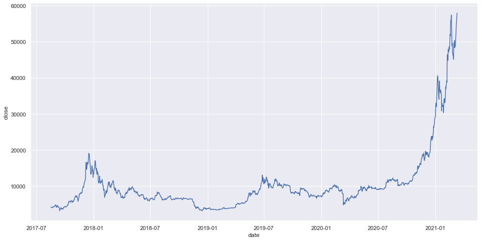

```python
# big lineplot
sns.lineplot(data=df['close'])
plt.show()
```

The Bitcoin price just skyrocketed in 2021!

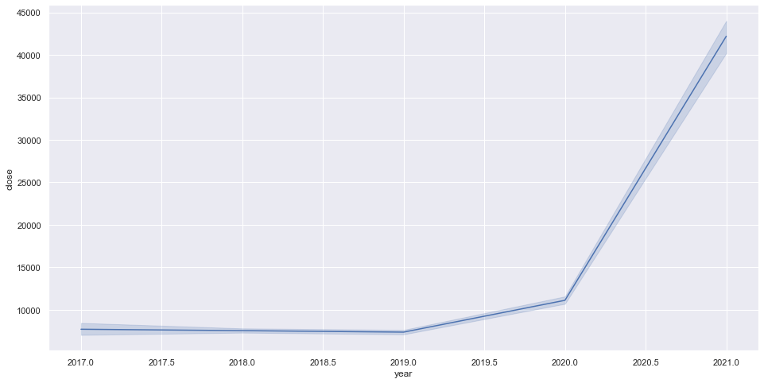

```python
# lineplot for years
sns.lineplot(x='year', y='close', data=df)
plt.show()
```

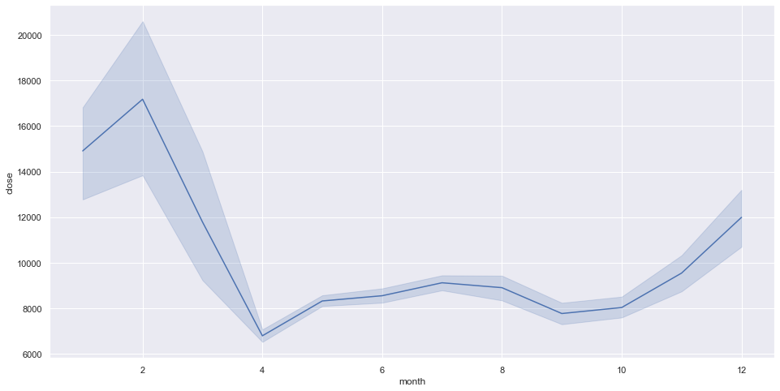

```python
# lineplot for months
sns.lineplot(x='month', y='close', data=df)
plt.show()
```

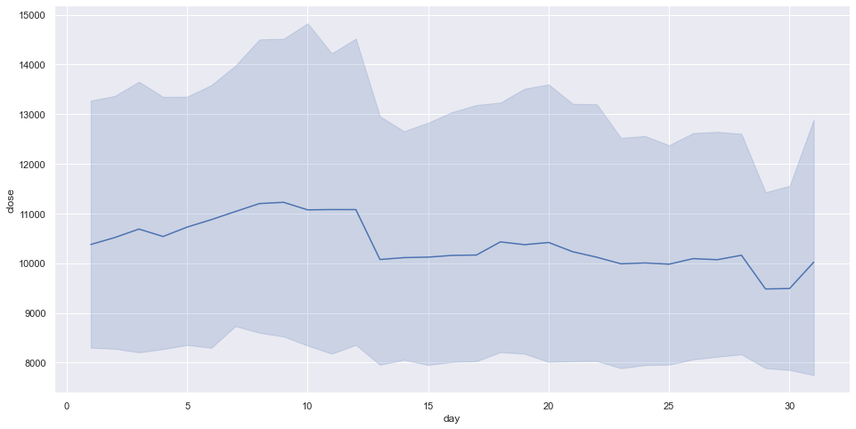

```python
# lineplot for days
sns.lineplot(x='day', y='close', data=df)
plt.show()
```

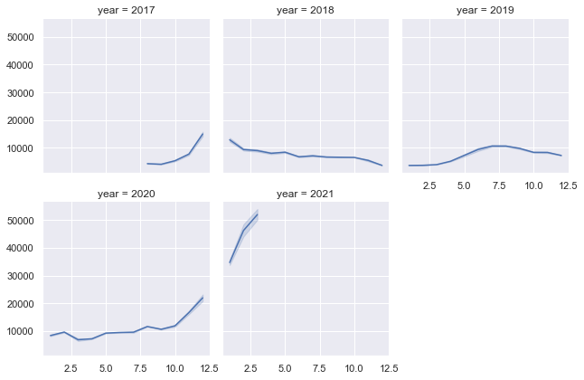

```python
# month by year
g = sns.FacetGrid(data=df, col='year', col_wrap=3)
g.map_dataframe(sns.lineplot, x='month', y='close')
plt.show()
```

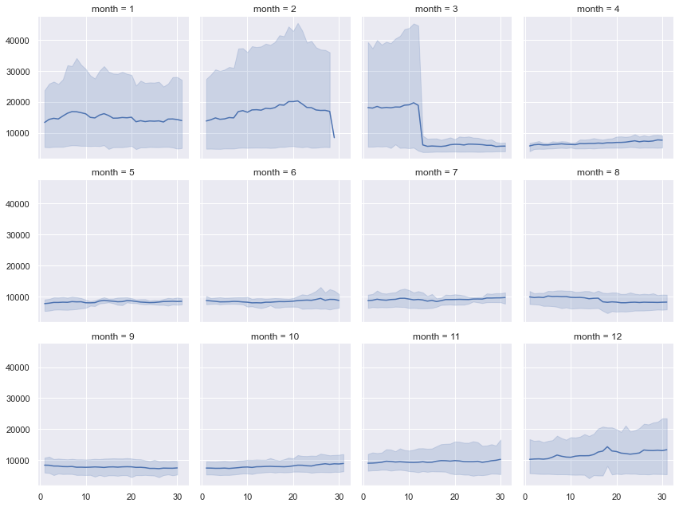

```python
# day by month
g = sns.FacetGrid(data=df, col='month', col_wrap=4)
g.map_dataframe(sns.lineplot, x='day', y='close')
plt.show()
```

##### 2.4.2 Boxplots

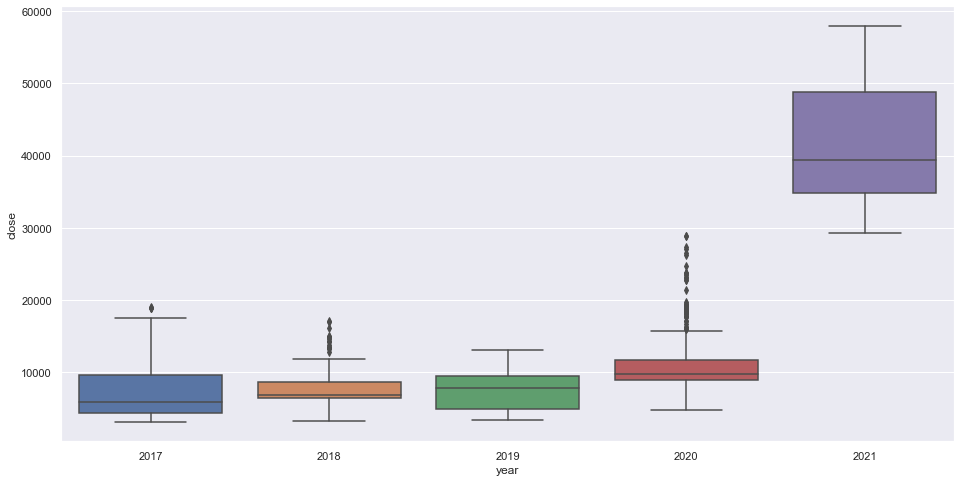

```python
# boxplots by year
sns.boxplot(x='year', y='close', data=df)
plt.show()
```

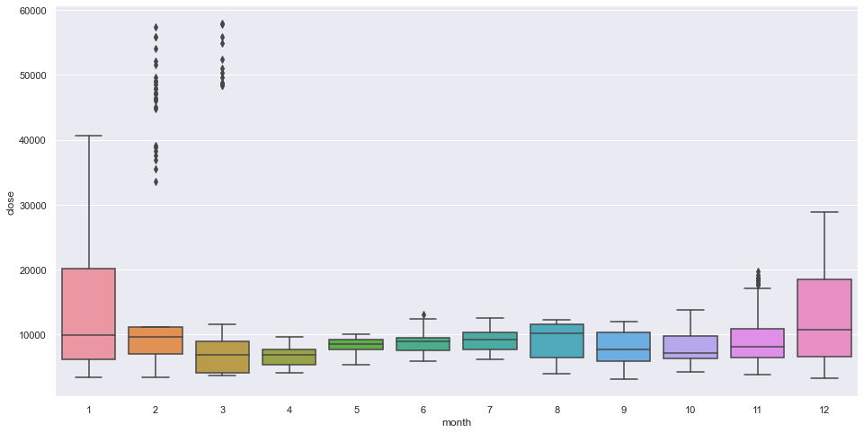

```python
# boxplots by month
sns.boxplot(x='month', y='close', data=df)
plt.show()
```

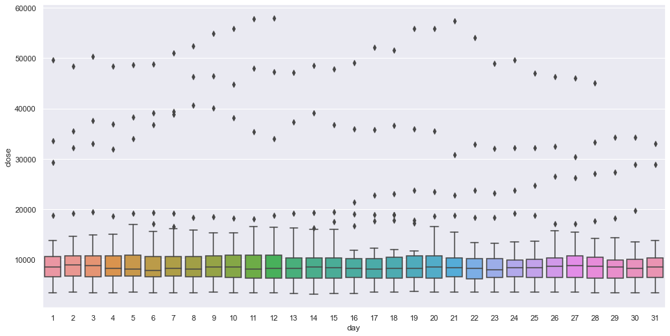

```python
# boxplots by day
sns.boxplot(x='day', y='close', data=df)
plt.show()
```

##### 2.4.3 Violin Plots

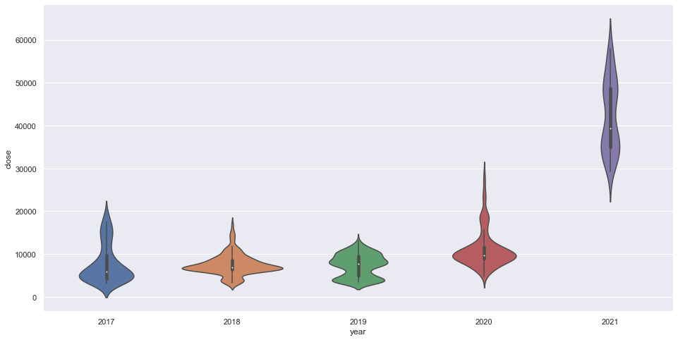

```python
# violinplots by year
sns.violinplot(x='year', y='close', data=df)
plt.show()
```

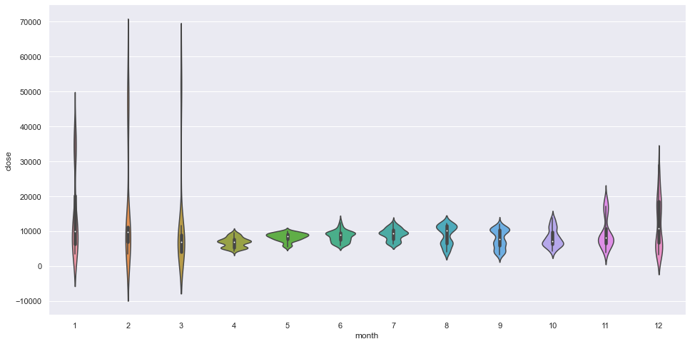

```python
# violinplots by month
sns.violinplot(x='month', y='close', data=df)
plt.show()
```

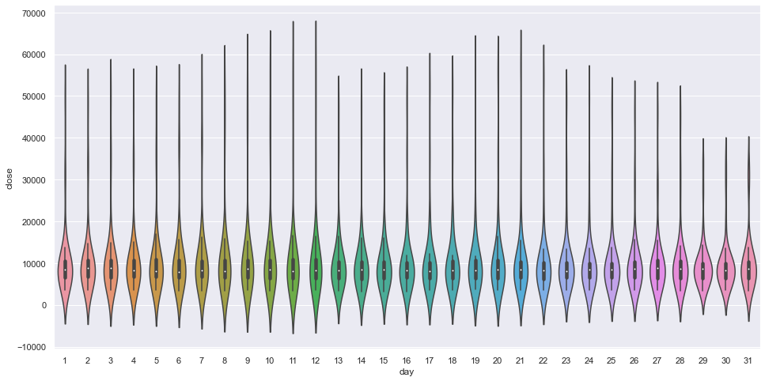

```python
# violinplots by day
sns.violinplot(x='day', y='close', data=df)
plt.show()
```

##### 2.4.4 Barplots

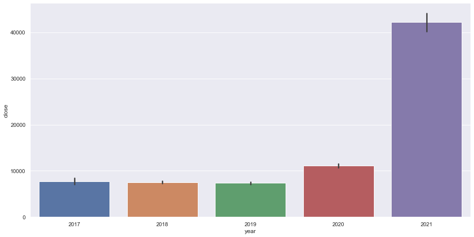

```python
# barplots by year
sns.barplot(x='year', y='close', data=df)
plt.show()
```

Even though 2021 just started, the average closing price is already a few times higher than in 2020!

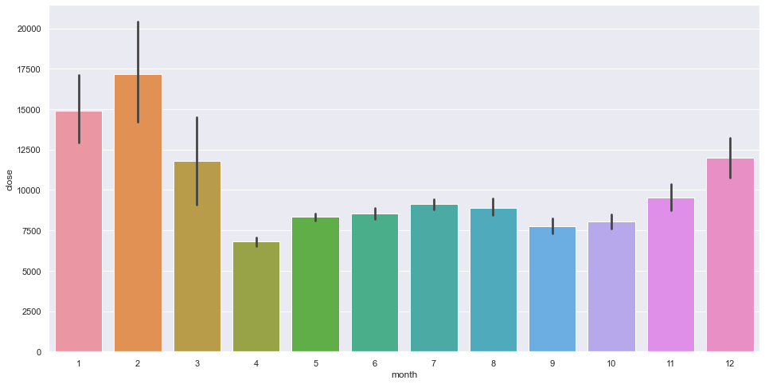

```python
# barplots by month
sns.barplot(x='month', y='close', data=df)
plt.show()
```

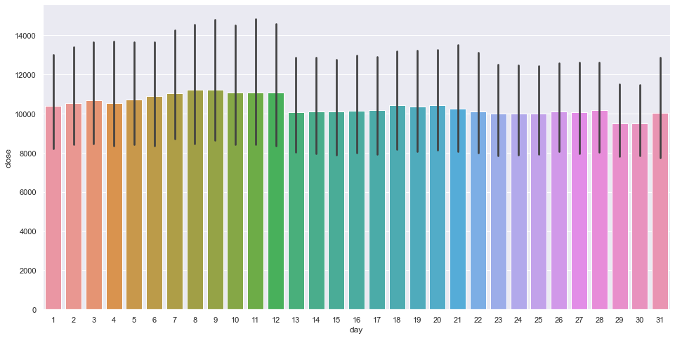

```python
# barplots by day
sns.barplot(x='day', y='close', data=df)
plt.show()
```

### 2.5 Additional dataset

Time permitting, I could also explore how different **exogenous variables** affect the trend / predictions. I have discussed some of them in the **Research Question** part!

Some exogenous variables could be:

- price of other stocks
- volume traded

## 3. Prediction task discussion

I want to get more experience in doing a **time series forecasting.** I want to predict what the closing price of bitcoin is going to be in the future.

Then, after I predict the price, I can extrapolate to other problems, for example, will the price increase or decrease, is it going to increase more than x% or less, etc.

I am not sure yet which models I will be using yet. However, in theory, I can try out some models I read about in the literature (please, refer to "Research Question: Contribution to the area of study" part where I discuss that).

**Comments from the advisor:**

The reference that compares the various methods to naive method sounds interesting!

The Extreme Learning Machine (ELM) is a funny name. Most of the time those models are just neural networks where one or more layers have the weights/biases set to random values and fixed. We saw in CS 1675 that hidden layers are essentially basis functions. If the hidden layer weights are fixed, then you basically create a fixed basis set (like the smoothing splines). The model is then really fast to fit, since the output layer is a linear model. The "extreme" part of ELM is usually just how extremely fast they can fit it (since it's a linear model in the output layer). That's why I think the name is funny, since most implementations of ELM I've come across is basically a linear basis function model.

MLP is just a neural neural network. The perceptron is a neuron. Multi-layer represents there are several layers in the network.

I don't know what Theta is.

Would be interesting to know what the features are that were supplied to a random forest model. I usually don't see RF used that often for forecasting.

There are bagged forecasting methods though which can be used .

If you would like to try a more advanced method, the packages discussed in the Rob Hyndman book in R have built in methods for neural networks.

The neural networks for time series applications are in the advanced forecasting chapter:

https://otexts.com/fpp3/nnetar.html

Those are just single hidden layer neural networks, but they serve as a nice starting point for the more advanced approaches.

Alternatively, you can consider dynamic harmonic regression which uses Fourier series as features in the model. The benefit of Fourier terms is that the complicated trends/cycles are being approximated by sin/cos waves. Those features can then be combined with the ARMA model for the correlated errors. The result is a rather flexible model.

The Fourier features are easy to include in the R package. It's just a line of code as shown here:

https://otexts.com/fpp3/dhr.html

The last thing to consider is to use STL to decompose the data and then apply a simple forecasting method to the seasonally adjusted data. This approach might be particularly interesting if you would group the data as the price at the end of the week. You would then have 52 weeks in the year or 52 seasons. A long seasonality is challenging to some methods, but STL would handle it pretty easily.

The book has a weekly seasonal example that uses this same approach to forecast the complex patterns:

https://otexts.com/fpp3/weekly.html

That model is compared to the dynamic harmonic regression model, which also works quite well.

You may want to try log transforming the price and fitting the models using the log-transformed closing price.

Yahoo finance lets you download bitcoin price back to Sept 2014 if you want more data. You can just download the data set as a CSV locally and work with it that way.

If you went back to 2015, that would give you a few years of data before the 60% crash in Bitcoin price between the end of 2017 and early 2018.

That would give you an interesting data set to work with since you could have a data set with a big "bubble" rise and crash.

If you would use data back to 2015, you could train with 2015-2017 and forecast into 2018. That way you could see how well the forecast handles the crash.

Then consider training on 2015-2018 and forecasting 2019.

I would imagine the most challenging task would be to forecast the behavior into 2021 with the huge rise you've shown in the report.

That said, what could be interesting to see if if you would forecast 3 weeks ahead as your cross-validation window. You could roll the data forward, so adding more data to the training set and forecasting a 3 week look-ahead horizon. This way you can see if some of the models are able to "incorporate" the rise seen in 2021 correctly.

This time series cross-validation style can be created in sklearn with the following method:

https://scikit-learn.org/stable/modules/generated/sklearn.model_selection.TimeSeriesSplit.html